# Prosper Loan Data Exploration

## Preliminary Wrangling

> Exploring dataset containing information about loans and its borrower

```python
# import all packages and set plots to be embedded inline
import numpy as np
import pandas as pd
import matplotlib.pyplot as plt
import seaborn as sb

%matplotlib inline
```

#### Loading Dataset

```python
file_name = 'C:\Learning\DataAnalyst\prosperLoanData.csv'
with open(file_name) as f:
    file_encoding = f.encoding

df = pd.read_csv(file_name, encoding = file_encoding)
df.head()
```

|  | ListingKey | ListingNumber | ListingCreationDate | CreditGrade | Term | LoanStatus | ClosedDate | BorrowerAPR | BorrowerRate | LenderYield | ... | LP_ServiceFees | LP_CollectionFees | LP_GrossPrincipalLoss | LP_NetPrincipalLoss | LP_NonPrincipalRecoverypayments | PercentFunded | Recommendations | InvestmentFromFriendsCount | InvestmentFromFriendsAmount | Investors |
| --- | --- | --- | --- | --- | --- | --- | --- | --- | --- | --- | --- | --- | --- | --- | --- | --- | --- | --- | --- | --- | --- |
| 0 | 1021339766868145413AB3B | 193129 | 2007-08-26 19:09:29.263000000 | C | 36 | Completed | 2009-08-14 00:00:00 | 0.16516 | 0.1580 | 0.1380 | ... | -133.18 | 0.0 | 0.0 | 0.0 | 0.0 | 1.0 | 0 | 0 | 0.0 | 258 |
| 1 | 10273602499503308B223C1 | 1209647 | 2014-02-27 08:28:07.900000000 | NaN | 36 | Current | NaN | 0.12016 | 0.0920 | 0.0820 | ... | 0.00 | 0.0 | 0.0 | 0.0 | 0.0 | 1.0 | 0 | 0 | 0.0 | 1 |
| 2 | 0EE9337825851032864889A | 81716 | 2007-01-05 15:00:47.090000000 | HR | 36 | Completed | 2009-12-17 00:00:00 | 0.28269 | 0.2750 | 0.2400 | ... | -24.20 | 0.0 | 0.0 | 0.0 | 0.0 | 1.0 | 0 | 0 | 0.0 | 41 |
| 3 | 0EF5356002482715299901A | 658116 | 2012-10-22 11:02:35.010000000 | NaN | 36 | Current | NaN | 0.12528 | 0.0974 | 0.0874 | ... | -108.01 | 0.0 | 0.0 | 0.0 | 0.0 | 1.0 | 0 | 0 | 0.0 | 158 |
| 4 | 0F023589499656230C5E3E2 | 909464 | 2013-09-14 18:38:39.097000000 | NaN | 36 | Current | NaN | 0.24614 | 0.2085 | 0.1985 | ... | -60.27 | 0.0 | 0.0 | 0.0 | 0.0 | 1.0 | 0 | 0 | 0.0 | 20 |

5 rows × 81 columns

```python
df.describe()
```

|  | ListingNumber | Term | BorrowerAPR | BorrowerRate | LenderYield | EstimatedEffectiveYield | EstimatedLoss | EstimatedReturn | ProsperRating (numeric) | ProsperScore | ... | LP_ServiceFees | LP_CollectionFees | LP_GrossPrincipalLoss | LP_NetPrincipalLoss | LP_NonPrincipalRecoverypayments | PercentFunded | Recommendations | InvestmentFromFriendsCount | InvestmentFromFriendsAmount | Investors |
| --- | --- | --- | --- | --- | --- | --- | --- | --- | --- | --- | --- | --- | --- | --- | --- | --- | --- | --- | --- | --- | --- |
| count | 1.139370e+05 | 113937.000000 | 113912.000000 | 113937.000000 | 113937.000000 | 84853.000000 | 84853.000000 | 84853.000000 | 84853.000000 | 84853.000000 | ... | 113937.000000 | 113937.000000 | 113937.000000 | 113937.000000 | 113937.000000 | 113937.000000 | 113937.000000 | 113937.000000 | 113937.000000 | 113937.000000 |
| mean | 6.278857e+05 | 40.830248 | 0.218828 | 0.192764 | 0.182701 | 0.168661 | 0.080306 | 0.096068 | 4.072243 | 5.950067 | ... | -54.725641 | -14.242698 | 700.446342 | 681.420499 | 25.142686 | 0.998584 | 0.048027 | 0.023460 | 16.550751 | 80.475228 |
| std | 3.280762e+05 | 10.436212 | 0.080364 | 0.074818 | 0.074516 | 0.068467 | 0.046764 | 0.030403 | 1.673227 | 2.376501 | ... | 60.675425 | 109.232758 | 2388.513831 | 2357.167068 | 275.657937 | 0.017919 | 0.332353 | 0.232412 | 294.545422 | 103.239020 |
| min | 4.000000e+00 | 12.000000 | 0.006530 | 0.000000 | -0.010000 | -0.182700 | 0.004900 | -0.182700 | 1.000000 | 1.000000 | ... | -664.870000 | -9274.750000 | -94.200000 | -954.550000 | 0.000000 | 0.700000 | 0.000000 | 0.000000 | 0.000000 | 1.000000 |
| 25% | 4.009190e+05 | 36.000000 | 0.156290 | 0.134000 | 0.124200 | 0.115670 | 0.042400 | 0.074080 | 3.000000 | 4.000000 | ... | -73.180000 | 0.000000 | 0.000000 | 0.000000 | 0.000000 | 1.000000 | 0.000000 | 0.000000 | 0.000000 | 2.000000 |
| 50% | 6.005540e+05 | 36.000000 | 0.209760 | 0.184000 | 0.173000 | 0.161500 | 0.072400 | 0.091700 | 4.000000 | 6.000000 | ... | -34.440000 | 0.000000 | 0.000000 | 0.000000 | 0.000000 | 1.000000 | 0.000000 | 0.000000 | 0.000000 | 44.000000 |
| 75% | 8.926340e+05 | 36.000000 | 0.283810 | 0.250000 | 0.240000 | 0.224300 | 0.112000 | 0.116600 | 5.000000 | 8.000000 | ... | -13.920000 | 0.000000 | 0.000000 | 0.000000 | 0.000000 | 1.000000 | 0.000000 | 0.000000 | 0.000000 | 115.000000 |
| max | 1.255725e+06 | 60.000000 | 0.512290 | 0.497500 | 0.492500 | 0.319900 | 0.366000 | 0.283700 | 7.000000 | 11.000000 | ... | 32.060000 | 0.000000 | 25000.000000 | 25000.000000 | 21117.900000 | 1.012500 | 39.000000 | 33.000000 | 25000.000000 | 1189.000000 |

8 rows × 61 columns

```python
df.info()
```

```
<class 'pandas.core.frame.DataFrame'>
RangeIndex: 113937 entries, 0 to 113936
Data columns (total 81 columns):
ListingKey                             113937 non-null object
ListingNumber                          113937 non-null int64
ListingCreationDate                    113937 non-null object
CreditGrade                            28953 non-null object
Term                                   113937 non-null int64
LoanStatus                             113937 non-null object
ClosedDate                             55089 non-null object
BorrowerAPR                            113912 non-null float64
BorrowerRate                           113937 non-null float64
LenderYield                            113937 non-null float64
EstimatedEffectiveYield                84853 non-null float64
EstimatedLoss                          84853 non-null float64
EstimatedReturn                        84853 non-null float64
ProsperRating (numeric)                84853 non-null float64
ProsperRating (Alpha)                  84853 non-null object
ProsperScore                           84853 non-null float64
ListingCategory (numeric)              113937 non-null int64
BorrowerState                          108422 non-null object
Occupation                             110349 non-null object
EmploymentStatus                       111682 non-null object
EmploymentStatusDuration               106312 non-null float64
IsBorrowerHomeowner                    113937 non-null bool
CurrentlyInGroup                       113937 non-null bool
GroupKey                               13341 non-null object
DateCreditPulled                       113937 non-null object
CreditScoreRangeLower                  113346 non-null float64
CreditScoreRangeUpper                  113346 non-null float64
FirstRecordedCreditLine                113240 non-null object
CurrentCreditLines                     106333 non-null float64
OpenCreditLines                        106333 non-null float64
TotalCreditLinespast7years             113240 non-null float64
OpenRevolvingAccounts                  113937 non-null int64
OpenRevolvingMonthlyPayment            113937 non-null float64
InquiriesLast6Months                   113240 non-null float64
TotalInquiries                         112778 non-null float64
CurrentDelinquencies                   113240 non-null float64
AmountDelinquent                       106315 non-null float64
```

[output cut: 31 more lines]

```
LP_CustomerPayments                    113937 non-null float64
LP_CustomerPrincipalPayments           113937 non-null float64
LP_InterestandFees                     113937 non-null float64
LP_ServiceFees                         113937 non-null float64
LP_CollectionFees                      113937 non-null float64
LP_GrossPrincipalLoss                  113937 non-null float64
LP_NetPrincipalLoss                    113937 non-null float64
LP_NonPrincipalRecoverypayments        113937 non-null float64
PercentFunded                          113937 non-null float64
Recommendations                        113937 non-null int64
InvestmentFromFriendsCount             113937 non-null int64
InvestmentFromFriendsAmount            113937 non-null float64
Investors                              113937 non-null int64
dtypes: bool(3), float64(50), int64(11), object(17)
memory usage: 68.1+ MB
```

```python
# Convert ListingCreationDate to datetime data type
df.ListingCreationDate = pd.to_datetime(df.ListingCreationDate)

# Credit Rating for rows prior to 2009 are in CreditGrade column and post july 2009 are in 'ProsperRating (Alpha)'
df['CreditRating'] = df.CreditGrade.fillna(df['ProsperRating (Alpha)'])

# convert the credit grade column into an ordered categorical data type
grade_sort = ['AA', 'A', 'B', 'C', 'D', 'E', 'HR', 'NC']
ordered_grade = pd.api.types.CategoricalDtype(ordered = True, categories = grade_sort)
df['CreditRating'] = df.CreditRating.astype(ordered_grade)

# convert the IncomeRange column into an ordered categorical data type
OrderedIncomeRange = ['Not displayed','Not employed','$0', '$1-24,999','$25,000-49,999','$50,000-74,999','$75,000-99,999','$100,000+']
OrderedIncomeRange = pd.api.types.CategoricalDtype(ordered = True, categories = OrderedIncomeRange)
df['OrderedIncomeRange'] = df.IncomeRange.astype(OrderedIncomeRange)

print(df.CreditRating.value_counts())
print(df.OrderedIncomeRange.value_counts())
```

```
C     23994
B     19970
D     19427
A     17866
E     13084
HR    10443
AA     8881
NC      141
Name: CreditRating, dtype: int64
$25,000-49,999    32192
$50,000-74,999    31050
$100,000+         17337
$75,000-99,999    16916
Not displayed      7741
$1-24,999          7274
Not employed        806
$0                  621
Name: OrderedIncomeRange, dtype: int64
```

### What is the structure of your dataset?

- Rows: 113937 records each detailing about a loan
- Columns: 81 features describing the loan and the borrower

### What is/are the main feature(s) of interest in your dataset?

- By finding which features of a borrower affects the profit/return for a loan, we should be able to predict if a new loan will be profitable or not.
  - LenderYield
  - EstimatedEffectiveYield
  - EstimatedReturn

### What features in the dataset do you think will help support your investigation into your feature(s) of interest?

#### Numeric variables

- CreditScoreRangeUpper
- DebtToIncomeRatio
- Investors

#### Categorical variables

- CreditGrade
- ProsperScore
- ListingCategory
- EmploymentStatus
- IsBorrowerHomeowner
- IncomeRange

## Univariate Exploration

#### LenderYield and Loan Term

We shall start with the 'LenderYield' which the main feature of interest in the dataset

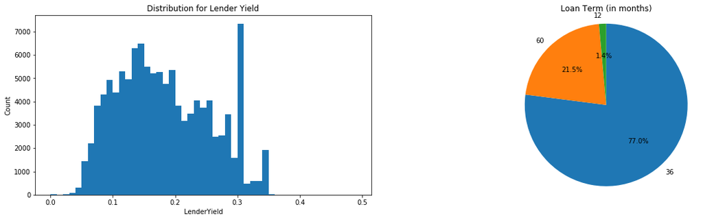

```python
# plotting a histogram using seaborn
plt.figure(figsize = [20, 5])
plt.subplot(1, 2, 1) # 1 row, 2 cols, subplot 1
bin_edges = np.arange(0, df.LenderYield.max() + 0.0001, 0.01)
sb.distplot(df.LenderYield, bins = bin_edges, kde = False, hist_kws = {'alpha' : 1})
plt.title('Distribution for Lender Yield')
plt.ylabel('Count')

plt.subplot(1, 2, 2) # 1 row, 2 cols, subplot 1
plt.pie(df.Term.value_counts(),
        startangle = 90, #start the first slice at vertically upwards
        counterclock = False, #plot the sorted counts in a clockwise fashion
        labels = df.Term.value_counts().index,
        autopct='%1.1f%%');
plt.axis('square')
plt.title('Loan Term (in months)');
```

#### Credit Rating and Credit Score

Main predictor variables of interest: CreditRating and CreditScoreRangeUpper

```python
# Finding invalid Credit Scrow data
df[df.CreditScoreRangeUpper < 450].CreditScoreRangeUpper.value_counts()
```

```
19.0     133
439.0      5
379.0      1
Name: CreditScoreRangeUpper, dtype: int64
```

[figure not shown]

```python
plt.figure(figsize = [20, 5])
plt.subplot(1, 2, 1) # 1 row, 2 cols, subplot 1
sb.countplot(data = df, x = 'CreditRating', color = sb.color_palette()[0])
plt.title('Number of records available for each Credit Rating')

# add annotations
n_points = df.shape[0]
tmp_grade = df.CreditRating.value_counts()
locs, labels = plt.xticks() # get the current tick locations and labels

# loop through each pair of locations and labels
for loc, label in zip(locs, labels):

    # get the text property for the label to get the correct count
    count = tmp_grade[label.get_text()]
    pct_string = '{:0.1f}%'.format(100*count/n_points)

    # print the annotation just below the top of the bar
    plt.text(loc, count-8, pct_string, ha = 'center', va ='baseline', color = 'black')

plt.subplot(1, 2, 2) # 1 row, 2 cols, subplot 2
bin_edges = np.arange(300, df.CreditScoreRangeUpper.max() + 10, 50)
plt.hist(data = df[df.CreditScoreRangeUpper.isna() == False], x = 'CreditScoreRangeUpper', bins = bin_edges, rwidth = 0.75)
# with rwidth = 0.75 parameter to the above histogram, the bars will take up 70% of the space, which emphasize that the data is discrete
plt.title('Distribution for Credit Score lower range')
plt.xlabel('CreditScoreRangeUpper')
plt.ylabel('Count');
```

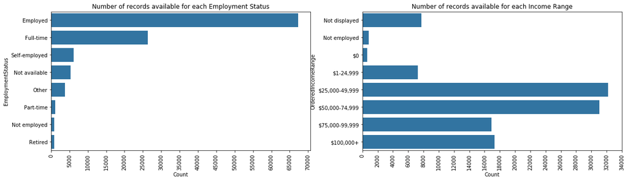

```python
plt.figure(figsize = [20, 5])

plt.subplot(1, 2, 1) # 1 row, 2 cols, subplot 1
sb.countplot(data = df, y = 'EmploymentStatus', order = df.EmploymentStatus.value_counts().index, color = sb.color_palette()[0])
plt.xticks(np.arange(0, 70001, 5000))
plt.xticks(rotation = 90)
plt.title('Number of records available for each Employment Status')
plt.xlabel('Count')

plt.subplot(1, 2, 2) # 1 row, 2 cols, subplot 2
sb.countplot(data = df, y = 'OrderedIncomeRange', color = sb.color_palette()[0])
plt.xticks(np.arange(0, 35000, 2000))
plt.xticks(rotation = 90)
plt.title('Number of records available for each Income Range')
plt.xlabel('Count');
```

Most of the loan is allocated to either Employed or Full-time employment status. And we have good amount of data in most of the income ranges

#### Investors

```python
 # Total rows
print(df.shape[0])

# Total rows with only one investor
print(df[df.Investors == 1].shape[0])

# Percentage of single investor = (Total rows with only one investor/Total rows)
print(100*df[df.Investors == 1].shape[0]/df.shape[0])
```

```
113937
27814
24.41173631041716
```

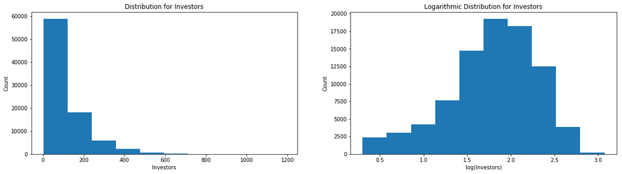

```python
plt.figure(figsize = [20, 5])
plt.subplot(1, 2, 1) # 1 row, 2 cols, subplot 1
plt.hist(df[(df.Investors.isna() == False) & (df.Investors != 1)].Investors)
plt.title('Distribution for Investors')
plt.xlabel('Investors')
plt.ylabel('Count')

# In the above plot, the data is highly skewed
# So, applying a logarithmic transform, the data will follow a normal distribution
plt.subplot(1, 2, 2) # 1 row, 2 cols, subplot 2
plt.hist(np.log10(df[(df.Investors.isna() == False) & (df.Investors != 1)].Investors))
plt.title('Logarithmic Distribution for Investors')
plt.xlabel('log(Investors)')
plt.ylabel('Count');
```

### Of the features you investigated, were there any unusual distributions? Did you perform any operations on the data to tidy, adjust, or change the form of the data? If so, why did you do this?

- Credit Rating for rows prior to 2009 are in CreditGrade column and post july 2009 are in 'ProsperRating (Alpha)'. So, both columns were merged into one column and converted into an ordered categorical data type.
- IncomeRange column is converted into an ordered categorical data type
- For Credit Rating unexpectedly, significant percent of the loan is given to HR- High Risk borrowers.
- Credit Score for about 133 rows were 19 which is invalid. So, there were not considered in the plot.

## Bivariate Exploration

#### Lender Yield vs Credit Rating

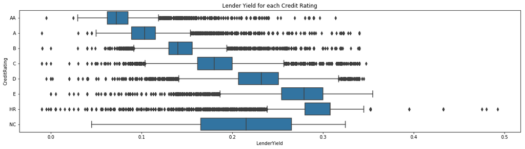

```python
plt.figure(figsize = [20, 5])
sb.boxplot(data = df, x = 'LenderYield', y = 'CreditRating', color = sb.color_palette()[0])
plt.title('Lender Yield for each Credit Rating');
```

From the above plot, we could see that the yield is higher for high risk credit rating and vice versa. We could also see that there are more outliers with lower yield for 'HR' and higher yield for 'AA'

#### Estimated Loss vs Credit Rating

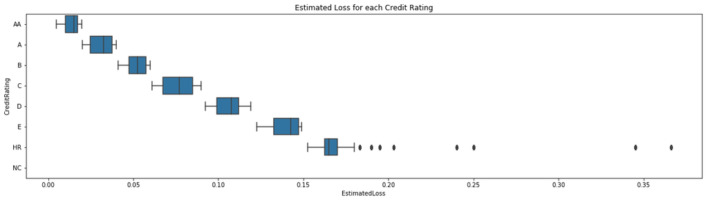

```python
plt.figure(figsize = [20, 5])
sb.boxplot(data = df[df.EstimatedLoss.isna() == False],
           x = 'EstimatedLoss', y = 'CreditRating', color = sb.color_palette()[0])
plt.title('Estimated Loss for each Credit Rating');
```

From the above plot we could see that the estimated loss is low for good credit score and vice versa. Also, we could see that there are outliers for 'HR' with much high loss.

#### Prosper Score vs LenderYield/EstimatedLoss

Using a seaborn scatter plot to get regression fitting. Note: Prosper Score is used here instead of Credit Rating, because regplot takes only numeric data

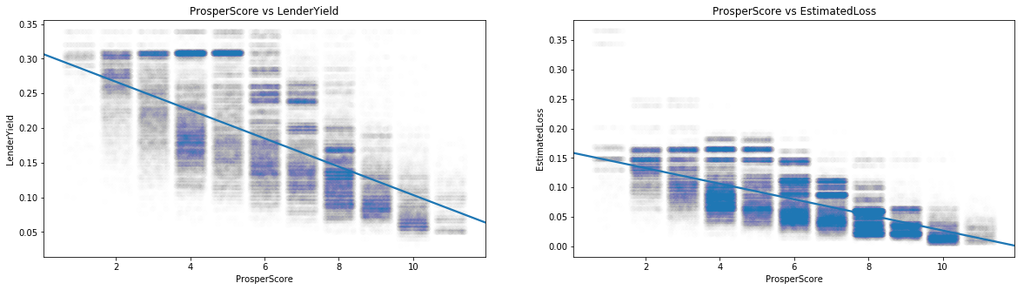

```python
plt.figure(figsize = [20, 5])
plt.subplot(1, 2, 1) # 1 row, 2 cols, subplot 1
# scatterplot with regression function fitting
sb.regplot(data = df[df.ProsperScore.isna() == False],
           x = 'ProsperScore', y = 'LenderYield', scatter_kws={'alpha':0.005}, x_jitter = 0.4)
# apply jitter if there is high amount of overlap in points
plt.title('ProsperScore vs LenderYield')

plt.subplot(1, 2, 2) # 1 row, 2 cols, subplot 2
# scatterplot with regression function fitting
sb.regplot(data = df[(df.EstimatedLoss.isna() == False) & (df.ProsperScore.isna() == False)],
           x = 'ProsperScore', y = 'EstimatedLoss', scatter_kws={'alpha':0.005}, x_jitter = 0.4)
# apply jitter if there is high amount of overlap in points
plt.title('ProsperScore vs EstimatedLoss');
```

Also, we could see that for Prosper score at 3, 4 and 5, there is more data near 0.3~0.31, which explains the exceptional peak on our very first histogram plot.

#### Credit Score vs LenderYield/EstimatedLoss

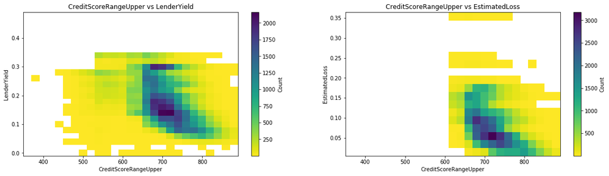

```python
plt.figure(figsize = [20, 5])
plt.subplot(1, 2, 1) # 1 row, 2 cols, subplot 1
bins_x = np.arange(350, 900 + 1, 20)
bins_y = np.arange(df.LenderYield.min(), df.LenderYield.max() + 0.001, 0.02)
plt.hist2d(data = df, x = 'CreditScoreRangeUpper', y = 'LenderYield',
           cmap = 'viridis_r', # reversing the default "viridis" color palette
           cmin = 0.5, # cell will only get colored if it contains at least one point
           bins = [bins_x, bins_y])
cbar = plt.colorbar()
cbar.set_label('Count')
plt.title('CreditScoreRangeUpper vs LenderYield')
plt.xlabel('CreditScoreRangeUpper')
plt.ylabel('LenderYield')


plt.subplot(1, 2, 2) # 1 row, 2 cols, subplot 2
bins_x = np.arange(350, 900 + 1, 20)
bins_y = np.arange(df.EstimatedLoss.min(), df.EstimatedLoss.max() + 0.001, 0.02)
plt.hist2d(data = df, x = 'CreditScoreRangeUpper', y = 'EstimatedLoss',
           cmap = 'viridis_r', # reversing the default "viridis" color palette
           cmin = 0.5, # cell will only get colored if it contains at least one point
           bins = [bins_x, bins_y])
cbar = plt.colorbar()
cbar.set_label('Count')
plt.title('CreditScoreRangeUpper vs EstimatedLoss')
plt.xlabel('CreditScoreRangeUpper')
plt.ylabel('EstimatedLoss');
```

Similar to other plots, the heat map also suggests the same. Also, we could see more count at 0.3 yield and 680 credit score which explains the peak at Yield histrogram.

#### Income Range vs LenderYield/EstimatedLoss

[figure not shown]

```python
plt.figure(figsize = [20, 15])
plt.subplot(2, 1, 1) # 2 row, 1 cols, subplot 1
sb.violinplot(data = df[df.OrderedIncomeRange.isna() == False],
              x = 'LenderYield', y = 'OrderedIncomeRange', color = sb.color_palette()[0])
plt.title('Estimated Return for each Income Range')

plt.subplot(2, 1, 2) # 2 row, 1 cols, subplot 2
sb.violinplot(data = df[(df.OrderedIncomeRange.isna() == False) & (df.EstimatedLoss.isna() == False)],
              x = 'EstimatedLoss', y = 'OrderedIncomeRange', color = sb.color_palette()[0])
plt.title('Estimated Return for each Income Range');
```

From the plots we could see that for higher income, the loss and yield are lower

### Talk about some of the relationships you observed in this part of the investigation. How did the feature(s) of interest vary with other features in the dataset?

We could see a correlation between Yield/Loss and Credit Rating and other features. We also see that there are considerable amount of outliers.

### Did you observe any interesting relationships between the other features (not the main feature(s) of interest)?

Income Range also has an relationship with Yield/Loss and similar to other plots, it has considerable amout of outliers as well

## Multivariate Exploration

#### ListingCategory vs CreditRating vs LenderYield

```python
# ListingCategory column mappings
# 0 - Not Available,
# 1 - Debt Consolidation,
# 2 - Home Improvement,
# 3 - Business,
# 4 - Personal Loan,
# 5 - Student Use,
# 6 - Auto,
# 7- Other,
# 8 - Baby&Adoption,
# 9 - Boat,
# 10 - Cosmetic Procedure,
# 11 - Engagement Ring,
# 12 - Green Loans,
# 13 - Household Expenses,
# 14 - Large Purchases,
# 15 - Medical/Dental,
# 16 - Motorcycle,
# 17 - RV,
# 18 - Taxes,
# 19 - Vacation,
# 20 - Wedding Loans

listing = ['Not Available', 'Debt Consolidation', 'Home Improvement', 'Business', 'Personal Loan', 'Student Use', 'Auto', 'Other', 'Baby&Adoption', 'Boat', 'Cosmetic Procedure', 'Engagement Ring', 'Green Loans', 'Household Expenses', 'Large Purchases', 'Medical/Dental', 'Motorcycle', 'RV', 'Taxes', 'Vacation', 'Wedding Loans']
df['ListingCategory'] = df['ListingCategory (numeric)'].apply(lambda x: listing[x])
df.ListingCategory.value_counts()
```

```
Debt Consolidation    58308
Not Available         16965
Other                 10494
Home Improvement       7433
Business               7189
Auto                   2572
Personal Loan          2395
Household Expenses     1996
Medical/Dental         1522
Taxes                   885
Large Purchases         876
Wedding Loans           771
Vacation                768
Student Use             756
Motorcycle              304
Engagement Ring         217
Baby&Adoption           199
Cosmetic Procedure       91
Boat                     85
Green Loans              59
RV                       52
Name: ListingCategory, dtype: int64
```

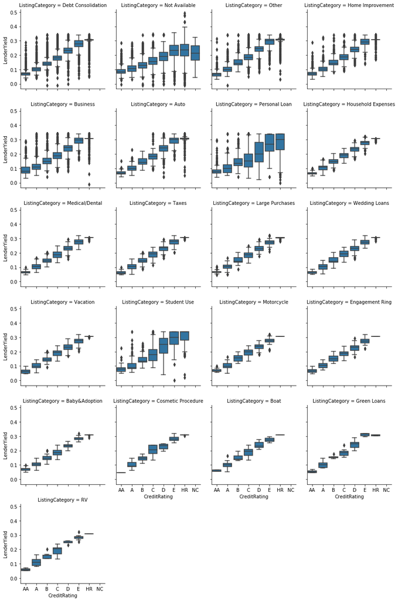

```python
g = sb.FacetGrid(data = df[df.ListingCategory.isna() == False],
                 col = 'ListingCategory',
                 col_order = df.ListingCategory.value_counts().index,
                 col_wrap = 4,
                 margin_titles = True)
g.map(sb.boxplot, 'CreditRating', 'LenderYield');
```

We have already seen the relationship between Credit Rating and Lender Yield in the previous plot. By breaking down to Listing category, we could see that for Personal Loan and Student use the data is distributed bit more than other catergories having less data. For Home improvement, we could see that comparatively it has less outliers in the bottom of the plot, suggesting higher yield with less risk for this category.

#### ProsperScore vs DebtToIncomeRatio vs LenderYield/EstimatedLoss

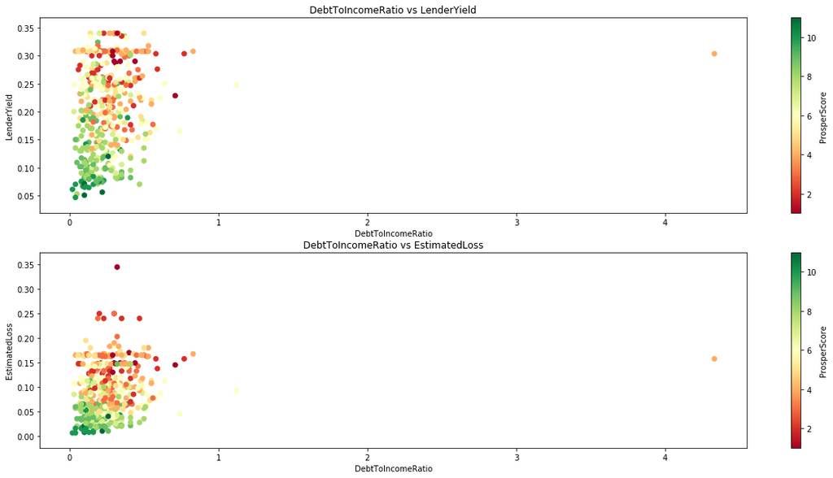

```python
plt.figure(figsize = [20, 10])
# plot matrix: sample 1000 so that plots are clearer and they render faster
samples = np.random.choice(df.shape[0], 1000, replace = False)
# Get sample from the rows that does not have NULL values in the features we are plotting
dfs = df[(df.ProsperScore.isna() == False) & (df.DebtToIncomeRatio.isna() == False) & (df.EstimatedLoss.isna() == False) & (df.IsBorrowerHomeowner.isna() == False) & (df.Investors.isna() == False) & (df.Investors != 1)].loc[samples,:]

plt.subplot(2, 1, 1) # 2 row, 1 cols, subplot 1
plt.scatter(data = dfs,
            x = 'DebtToIncomeRatio', y = 'LenderYield', c='ProsperScore', cmap = 'RdYlGn')
cbar = plt.colorbar()
cbar.set_label('ProsperScore')
plt.title('DebtToIncomeRatio vs LenderYield')
plt.xlabel('DebtToIncomeRatio')
plt.ylabel('LenderYield')

plt.subplot(2, 1, 2) # 2 row, 1 cols, subplot 2
plt.scatter(data = dfs,
            x = 'DebtToIncomeRatio', y = 'EstimatedLoss', c='ProsperScore', cmap = 'RdYlGn')
cbar = plt.colorbar()
cbar.set_label('ProsperScore')
plt.title('DebtToIncomeRatio vs EstimatedLoss')
plt.xlabel('DebtToIncomeRatio')
plt.ylabel('EstimatedLoss');
```

We have already seen the relationship between ProsperScore and LenderYield/EstimatedLoss. And with DebtToIncomeRatio we do not see any relationship

#### Investors vs IsBorrowerHomeowner vs LenderYield

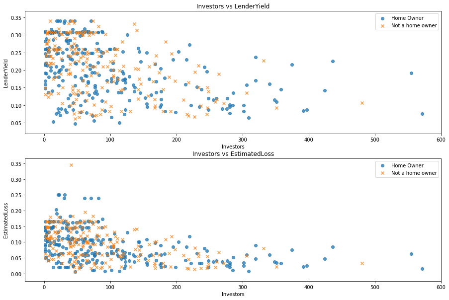

```python
plt.figure(figsize = [15, 10])

plt.subplot(2, 1, 1) # 2 row, 1 cols, subplot 1
plt.scatter(data = dfs[(dfs.IsBorrowerHomeowner == True)], x = 'Investors', y = 'LenderYield', alpha = 0.75, marker = 'o')
plt.scatter(data = dfs[(dfs.IsBorrowerHomeowner == False)], x = 'Investors', y = 'LenderYield', alpha = 0.75, marker = 'x')
plt.legend(['Home Owner', 'Not a home owner'])
plt.title('Investors vs LenderYield')
plt.xlabel('Investors')
plt.ylabel('LenderYield')

plt.subplot(2, 1, 2) # 2 row, 1 cols, subplot 2
plt.scatter(data = dfs[(dfs.IsBorrowerHomeowner == True)], x = 'Investors', y = 'EstimatedLoss', alpha = 0.75, marker = 'o')
plt.scatter(data = dfs[(dfs.IsBorrowerHomeowner == False)], x = 'Investors', y = 'EstimatedLoss', alpha = 0.75, marker = 'x')
plt.legend(['Home Owner', 'Not a home owner'])
plt.title('Investors vs EstimatedLoss')
plt.xlabel('Investors')
plt.ylabel('EstimatedLoss');
```

We don't see any relationship with IsBorrowerHomeowner. But we could see that the trend when number of investors goes higher the Yield and Loss goes lower.

#### Timeline

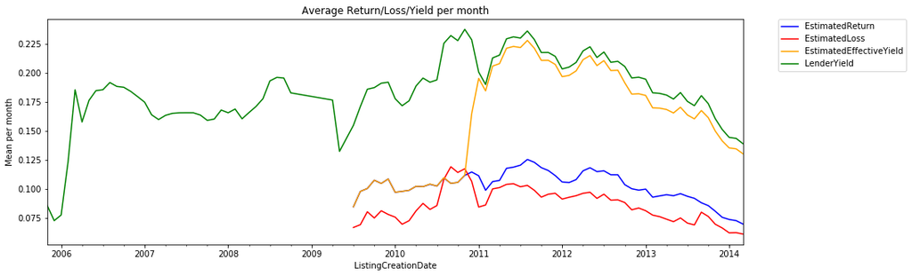

```python
plt.figure(figsize = [15, 5])

monthly = df.ListingCreationDate.dt.to_period("M")

return_per_month = df[df.EstimatedReturn.isna() == False].groupby(monthly).EstimatedReturn.mean()
loss_per_month = df[df.EstimatedLoss.isna() == False].groupby(monthly).EstimatedLoss.mean()
yield_per_month = df[df.EstimatedEffectiveYield.isna() == False].groupby(monthly).EstimatedEffectiveYield.mean()
lender_yield_per_month = df[df.LenderYield.isna() == False].groupby(monthly).LenderYield.mean()

return_per_month.plot(color = 'blue')
loss_per_month.plot(color = 'red')
yield_per_month.plot(color = 'orange')
lender_yield_per_month.plot(color = 'green')

plt.legend(bbox_to_anchor=(1.05, 1), loc=2, borderaxespad=0.)
plt.ylabel('Mean per month')
plt.title('Average Return/Loss/Yield per month');
```

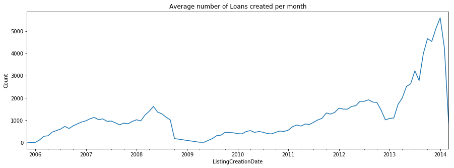

```python
plt.figure(figsize = [15, 5])
count_per_month = df.groupby(monthly).ListingKey.count()
count_per_month.plot()
plt.title('Average number of Loans created per month')
plt.ylabel('Count');
```

When we look at the monthly mean data, there is a huge increase in the number of loans in 2013. But the Return/Yield trends to go lower in 2013.

### Talk about some of the relationships you observed in this part of the investigation. Were there features that strengthened each other in terms of looking at your feature(s) of interest?

Here, we could see, the relationship between Yield/Loss and CreditRating, ProsperScore and Investors. We also saw how the outliars are placed for each ListingCategory.

### Were there any interesting or surprising interactions between features?

DebtToIncomeRatio and IsBorrowerHomeowner features does not affect the Yield/Loss. And it is very useful to see mean per month in a timeline to get the trend.